Tholonia - 021-PREDETERMINISM  
The Existential Mechanics of Awareness  
Duncan Stroud  
Published: January 15, 2020  
Updated: Updated: Mar 26, 2026 v8.0.89  
Welkin Wall Publishing  
ISBN-10:  
ISBN-13: 978-1-6780-2532-8  
Copyright ©2020 Duncan Stroud CC BY-NC-SA 4.0

This book is an open sourced book. This means that anyone can contribute changes or updates. Instructions and more information at https://tholonia.github.io/the-book (or contact the author at duncan.stroud@gmail.com). This book and its on-line version are distributed under the terms of the Creative Commons Attribution-Noncommercial-ShareAlike 4.0 International (CC BY-NC-SA 4.0) license, with the additional proviso that the right to publish it on paper for sale or other for-profit use is reserved to Duncan Stroud and authorized agents thereof. A reference copy of this license may be found at https://creativecommons.org/licenses/by-nc-sa/4.0/. The above terms include the following: Attribution - you must give appropriate credit, provide a link to the license, and indicate if changes were made. You may do so in any reasonable manner, but not in any way that suggests the licensor endorses you or your use. Noncommercial - You may not use the material for commercial purposes. Share Alike - If you remix, transform, or build upon the material, you must distribute your contributions under the same license as the original. No additional restrictions - you may not apply legal terms or technological measures that legally restrict others from doing anything the license permits. Notices - You do not have to comply with the license for elements of the material in the public domain or where your use is permitted by an applicable exception or limitation. No warranties are given. The license may not give you all of the permissions necessary for your intended use. For example, other rights such as publicity, privacy, or moral rights may limit how you use the material.

# 21: PREDETERMINISM

###### Free will exists, but its options are limited

##### **Synopsis:** Energy movement follows predetermined paths of least resistance through tholonic fields, creating the appearance of free will within predetermined possibilities. Archetypes tend toward order while instances tend toward chaos. Patterns emerge from the thologram’s hierarchical structure, with stable cores and dynamic edges where new paths form. Randomness originates from the singular event of A&I, propagating through all subsequent events. Coincidences represent tholonic resonance between instances sharing archetypal origins. Reality shifts occur through collective memory and contextual patterns rather than individual experiences. The direction of intention moves cyclically between creating order from low-entropy chaos and generating high-entropy chaos from order, reflecting existence’s fundamental balancing mechanism.

##### **Keywords:** predetermined paths, tholonic fields, archetypal stability, instantiation entropy, tholonic resonance, intention cycles

Chapter 20 closed by asking what governs the paths an archetype follows once it is in motion. If the thologram provides the structural channels through which all energy flows, and archetypes are the stable low-entropy nodes at which those channels converge, then the paths must be in some sense fixed before any particular tholon begins its journey along them. The answer begins with a surprisingly simple image from everyday physics.

Remember the explanation of how a lightning rod works? It simply creates a path of least resistance between 2 different states that seek balance, and, as energy always travels the path of least resistance, lightning will always seek the lightning rod over a brick chimney. We can say that the path of the lightning was predetermined by the laws of physics before the lightning event, just as we can say that the lightning only came into existence because such a path even existed in the 1<sup>st</sup> place. In other words, the instance of lightning is a consequence of the preexisting energy fields.

The same concept holds for the thologram in that there can be almost countless combinations of archetypes and, therefore, almost countless connections of tholons between the “beginning” and the “end”. This implies that within the thologram exists every path of creation and/or growth that is possible *at that moment in time*, but the paths that will be traveled are those that represent the path of least resistance, and what we see as reality around us is a consequence of energy moving through those paths.

As new combinations emerge, new paths emerge, but for the most part, these paths will emerge from the “bottom” or end-points of the hierarchy, as these are the most unstable and dynamic, similar to the unstable borders of a fractal. Each tholon represents a “step” in the path. New paths are rarer as we move up the hierarchy, because higher-order tholons have achieved a stable state held in place by the induction of their parents and children, and short of a radical change in energy, they will not change. The force of the energy that would be needed to effect a change is inversely proportional to their ancestors and proportional to their descendants. This is why reality “is confined by rules that may be shockingly narrow,” to quote Charles S. Cockell from his book “The Equations of Life: How Physics Shapes Evolution,” and suggests that form and life across the Universe may not vary as much as we might imagine.

An example of these new emerging paths would be the creation of a new element in the periodic chart. Nearly all elements past uranium (element 92) are synthetic and created in laboratories. While trace amounts of neptunium (93) and plutonium (94) occur naturally, all elements from americium (95) onward are entirely artificial. These synthetic elements are extremely unstable, unsustainable, and don’t last very long. A new stable path, even a little way up from the “bottom,” would dramatically alter reality.

Starting from the beginning, at the first moment of awareness of a non-existent dot in the void of nothingness, A&I began self-replicating into smaller and smaller divisions. These divisions stop at some point where no sustainable patterns can be achieved, perhaps because the difference is too small, weak, or for another reason. The depth of a tholon’s scope can be described as the difference between 2 states, the delta of the duality of that scope, similar to the definition of voltage we saw above, which presumably gets smaller and smaller with each generation (but not necessarily).

As the parents and children of a tholon change, so will that tholon adapt to these changes by adjusting its scope. In doing so, the thologram is *problem-solving* in real-time. More than that, this adaptation is heuristic, i.e., a manner based on experience. How? Because the (only successful) changes made in the past affected the entire thologram. The consequence of those changes defines the context of each tholon’s current condition.

The working hypothesis is that the thologram has a memory of everything that has ever happened to it that resulted in a successful change. This chain of records continues with each tholon created. However, there can be many tholons occupying the same space because of the embedded nature of tholons, so if you reference a tholon at the “bottom” of the thologram, you are implicitly referencing every parent tholon in the chain of tholons back to the very 1<sup>st</sup> tholon. This suggests that any instance of a tholon is also an implicit reference to many tholons and the path or chain that connects them.

What this tells us is that each instance is a 3D perspective of a very multi-dimensional form of energy that describes one “path” from the first tholon to the tholon in question, but which we 3D dwellers experience as past, present, and future (like the example given earlier of a 3D ball passing through 2D space).

Two strangers, Bob and Carol, bump into each other at the butcher shop. This interaction is the result of countless steps starting with the Big Bang, or whatever the 1<sup>st</sup> event was that kick-started the Universe. The path from the 1<sup>st</sup> moment of creation to the current instance that it took for Bob and his ancestors to arrive at this point and time, we’ll call path B, and the same for Carol, we’ll call path C. Path B and path C already existed in the thologram. Bob and Carol are the current instance of the fields of these two paths connecting because it was the path of least resistance, for whatever reasons, like the two fields that connect to create lightning. There are effectively an infinite number of paths and their fields, but the point where Bob and Carol meet is the only point where the two fields, of which they are the current instances, connect. If reality itself is the memory store, anything that emerges from this meeting will inherit the “implicit information” of both paths that led to their meeting.

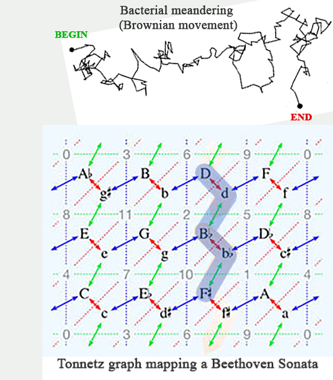

Every path that can be traveled by any instance already exists because the fields already exist. The path is the expression of the fields interacting. We tend to wander through this matrix of possibilities in a way that appears aimless, similar to how bacteria wander about in their puddles of plasma. From the tholonic perspective, these paths are determined by various cooperative and competing tholonic fields.

One of the best instances of this that is easily understood is music. Consider that a finite number of notes exist, but an almost infinite number of tunes can be written within those notes. If we mapped every combination of notes, the tune could be seen as a path on that map. This is more than just a thought experiment… it’s an actual undertaking by music theorist Julian Hook, who described in his article “Exploring Musical Space”[^1] how the harmonic path of a Beethoven sonata can be visualized on a *Tonnetz* graph (left)… a graph that happens to look just like a 2D tholon map. In this example, the notes act like the fields, and the playing of those notes represents energy moving through these fields, forming music, lightning, plants, rivers, neurons, and everything else.

Music also demonstrates how certain patterns can lay the foundations for other patterns and expressions. For example, there are many different scales, such as *pentatonic*, which has 5 notes per octave, or the *Western Major Scale*, with the classic 7 notes most Westerners are familiar with. Sound occurs when energy is applied to matter, and notes represent the *dots* that we have identified within that chaos of white noise through our power of reasoning. We form patterns and connect these dots in the sea of chaos that is all sound, and by doing so, we create “music”. We describe white noise as all frequencies expressed at once. Still, it is equally accurate to describe white noise as every possible pattern of all possible notes being performed at once, similar to how incoherent white light is an infinite number of coherent frequencies and directions. This tells us that all possible forms of music, all songs, rhythms, beats, arrangements, etc., already exist within that white noise, and all we can do is discover them.

This discovery is not limited to humans; we see the same thing in songbirds. The scientific understanding of this has evolved significantly over time.

In 2012, *Science Magazine* published an article citing a report from the *Journal of Animal Behavior* titled “Is birdsong music? Evaluating harmonic intervals in songs of a Neotropical songbird”[^2] that concluded that any musicality we might hear in a bird’s song is nothing more than projection on the human’s part. Two years later, however, they published an article that cites a later study from the *Proceedings of the National Academy of Sciences*, titled “Overtone-based pitch selection in hermit thrush song: Unexpected convergence with scale construction in human music”[^3], which concluded that birds most likely choose the notes they sing and that these notes are the same notes that we humans have also selected to create our musical scales.

The tholonic position is simply that some patterns are more stable and efficient than others, such as the harmonic series, so we would expect to see it in music, bird songs, fungal growth, orbits, and countless other contexts.

Even in the world of bacterial meandering, we see a pattern. Not surprisingly, it is the inverse of a Bell curve: a group of bacteria released at the same time starts relatively coherent and eventually disperses into incoherence. It’s almost (or exactly) as if the instances of creations emerge from a tholon’s Bell curve in a manner inverse to that Bell curve, like a kind of balancing factor, much like the way a positive charge will automatically create a pairing with a negative charge, or how the amount of water that falls to the Earth (rain) is equivalent to the amount of water that rises into the sky (evaporation) from the Earth.

States of order create states of chaos, which create new states of order. It also appears that archetypes are always decreasing in entropy, becoming more ordered, while their instances are always increasing in entropy. This is possible because there is no *arrow of time*, only an *arrow of order* in the world of archetypes.

#### **Key 82:** Archetypes tend toward order, while instances tend toward chaos.

In the early generations of the thologram, the number of paths is limited, but as additional generations are added, the number increases. This movement may appear random, but not only does it disperse according to a Bell curve, but it also follows the same self-similar and fractal rules as the thologram[^4].

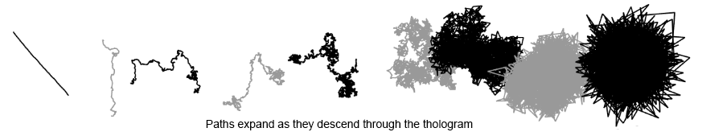

This is effectively predeterminism, although there are so many possible paths created by the unfolding, explicating, and instantiating of every possible combination of sustainable patterns that can establish a balance between differing fields that predeterminism doesn’t practically apply. So we may have free will, but only in determining which predetermined path we follow, at least from the tholonic perspective.

If energy always travels the path of least resistance, then why doesn’t everyone and everything follow only a single path? Wouldn’t that suggest that energy doesn’t always travel the path of least resistance? It would if everything were the same, but thanks to chaos, the slightest change can have radical results. Still, chaos doesn’t create randomness, so where does the initial random change come from?

There only needs to be a single random event, or random seed, at the beginning of creation, and the power laws and chaos will create new events from that single seed, which will appear and act as random. What that physical event was is unknown, but in the tholonic model, the 1st and only true random event, an event that has no reason, no cause, is the appearance of the 0-dimensional dot which came into existence via Awareness and Intention. Every event that results from that 1st event, which is all events, has some random seed built into it. Still, Awareness and Intention, and perhaps *only* A & I, can create random events. The specifics of how this would work are unknown, but the point is that randomness is built into creation and existence.

But another concept to consider is the path of least resistance. As demonstrated by the effort expended in listening to a lecture on “Post-modern Fashion in Appalachia” versus digging a ditch, resistance can vary widely. What is least resistant for me is not what is least resistant to a sociology professor teaching “Doctor Seuss and Y(our) World” (an actual class at, coincidentally, Appalachian State University). This resistance is not electrical, thermodynamic, or mechanical, nor is the psychic energy it resists; yet this psychic energy is just as influential in deciding which path will be chosen. As everything is energy, and energy travels the path of least resistance in the process of balancing itself, whatever this psychic energy is, it must also be traveling the path of least resistance and attempting to balance itself.

Although a bit of a tangent, and undoubtedly worthy of more than a paragraph, it’s worth stating here that the idea of reincarnation has a tholonic explanation, which goes something like the following:

What some people believe to be past-life experiences are collective memories associated with the path we happen to be instantiating, or, if you will, traveling, and which we identify with mainly because our ego tends to relate these inherited and embedded memories (and everything else, apparently) to ourselves. There will naturally be more instances (of people) in these well-worn paths of archetypes simply because these paths are the paths of lesser resistance. Hence, many individuals will share the same memories of this path, which explains why many believe they were some grand historical figure in a past life.

This is not an idea limited to reincarnation, as numerous patterns dominate and influence the ideas that make up our view of reality at different times. For this reason, reality, from atoms to ideas, also differs across time. Take the concept of an atom, which is based on the patterns of reality we happen to be discovering at this point in our journey. At other times, this concept didn’t exist, or if it did, it did so quite differently. In the future, it may disappear altogether. There may come a time (or was a time) when what we see as atoms is seen as spirits, bits of intelligence, or 3D projections of a 248D magic crystal, or something we are incapable of imagining at this time.

The laws that apply in the context of atoms, now and in the future, will also apply to “spirits” or bits of intelligence, or however we choose to see them, and these laws will also be understood within the context and scope of the time. Just in the last 90 years alone, the model of the electron has morphed from a type of “mist” (1905) to little orbiting particles (1911) to standing wave patterns (1924) to the probability fields of quantum mechanics that extend to the edge of an entangled Universe (1926).

While every tholon is unique, its instances will usually be very similar, as there are many instances for every archetype. Likewise, there is no reason why there couldn’t be multiple near-identical instances of a tholon, and many reasons why there could be. This concept has been around for a long time in the form of *doppelgangers*, twin strangers, alter egos, and changelings, and has found a new home in concepts such as cloning and the multiverse.

Metaphysics has a similar concept of a *soul family*, which are groups of souls that share much of the same “structure”, metaphysical DNA, so to speak, as they are part of the same collective of an encompassing “soul”. Naturally, such concepts would appear as we observe them in nature, especially among living organisms: many leaves from one branch, many branches from one tree, and many trees from one root system. Modern science, with the discovery of DNA, provides further support for this concept.

Tholons are more than just archetypes. They are archetypes of ideas, contexts, situations, experiences, and concepts. As such, we should expect to see “clones” or “twins” of situations, contexts, experiences, etc. We do, and we tend to call them “coincidences”. Here are some of the more popular or well-known stories of “coincidences” that, when viewed tholonically, might offer insight.[^5]

### Laura Buxton

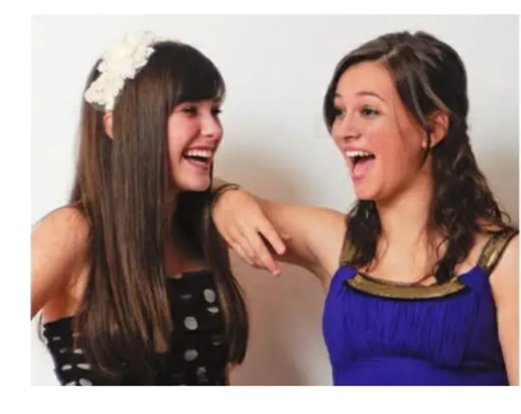

“In June of 2001, a 10-year-old girl named Laura Buxton released a balloon with her name and address on it. That balloon floated 140 miles and landed in the backyard of a house where a 10-year-old girl named Laura Buxton also lived. On the day of the meeting, the two girls wore essentially the same outfit (a pink sweater and jeans). The girls were the same height, which was unusual because they were both tall for their age. They both had brown hair and wore it in the same style. They both had three-year-old black Labrador Retrievers at home, as well as gray pet rabbits. They both had guinea pigs, which were the same color and even had the same orange markings on their hindquarters. It was almost as though these two Laura Buxtons were the same person”.[^6] On the right is a picture of the two Laura Buxtons, who are still friends today.

*Here, there are two contextually separated instances of one tholonic path. What is fascinating about this is that the 2 instances of the same archetype would naturally have an existing connection, a tholonic resonance. The red balloon offered the most efficient way for these instances to make contact, given their context. Why was there a “need” to make contact at all? Tholonically, they were already connected; it just took time for that connection to instantiate. We could also think of these 2 instances as ‘entangled’ as they both emerged from the same archetype. This connection, or entanglement, was instantiated via the red balloon that carried the address between the receiving side and the transmission side of this split instance.*

### King Umberto I’s double

In Monza, Italy, King Umberto I dined at a small restaurant, accompanied by his aide-de-camp, General Emilio Ponzia-Vaglia. When the owner took King Umberto’s order, the King noticed that he and the restaurant owner were virtual doubles, in face and in build. Both men began discussing the striking similarities between them and found many more.

- Both men were born on March 14th (Pi-day), 1844.
- Both men had been born in the same town of Turin, Italy.
- Both men married a woman with the same name, Margherita.
- The restaurateur opened his restaurant the same day that King Umberto was crowned King of Italy.
- On 29th July 1900, King Umberto was informed that the restaurateur had died that day in a mysterious shooting accident. As he expressed his regret, an anarchist assassinated him in the crowd.

*This looks like a single archetype that instantiated in different contexts, similar to the Buxton girls, albeit in more dramatically different contexts. This may also suggest that tholonic contexts are also archetypal, meaning there are “archetypal contexts” and “instantiated contexts”.*

### Twin boys, twin lives

Twin Ohio boys were separated at birth and adopted by different families. Neither family knew the other, and both named their sons James. Both James grew up not knowing the other, yet both sought law-enforcement training. Both had abilities in mechanical drawing and carpentry, and each had married a woman named Linda. Their sons were named James Alan and James Allan. The twin brothers also divorced their wives and married other women, both named Betty, and they both owned dogs named Toy. Forty years after their childhood separation, the two men were reunited. (Source: Reader’s Digest, January 1980)

*This is 2 instances of the same tholon and context at birth and in life, but it also suggests that other tholonic archetypes, such as those of the wives, the children, and even the dogs, were an integral part of the contextual instances.*

### Three strangers on a train

In the 1920s, 3 Englishmen were traveling separately by train through Peru. At the time of their introduction, they were the only men in the railroad car. Their introductions were more surprising than they could have imagined. One man’s last name was Bingham, and another’s was Powell. The remaining man announced that his last name was Bingham-Powell. None were related in any way. (Source: Mysteries of the Unexplained)

*Here, these men, although having different lives, clearly shared some contextual details. Does this suggest that even our names can be instances of a pattern? I have some personal experience with this. Since childhood, I have had a strange and nostalgic fascination with El Paso, Texas, especially its Old West history. I had never been to El Paso before, but I drove through the West Texas desert town in my 40s at around 4 AM. It was an ugly town, but I found it incredibly alluring for reasons I could not explain. Years later, I discovered that a well-known Old West lawman of El Paso and I shared the same name. I can’t say whether that is why I felt the way I did about El Paso, but there is no question that my name and El Paso share a strong tholonic bond so that some resonance would exist between the two concepts.*

### Richard Parker

Edgar Allan Poe wrote a story called “The Narrative of Arthur Gordon Pym”. This story was about 4 survivors of a shipwreck who were in an open boat for many days before they decided to kill and eat the cabin boy named Richard Parker. Some years later, in 1884, the *Mignonette*, a 52-foot English yacht, was capsized by a wave as they traveled northwest of the Cape of Good Hope. The survivors found themselves together in an open boat for many days. Eventually, the 3 senior members of the crew killed and ate the cabin boy, whose name was Richard Parker.

*Here, a pattern took form as both a story and an experience. Perhaps Poe was able to tune into certain patterns. That could be what creativity or genius is: the ability to tap into patterns that have yet to become instantiated. P.S. The men served only 6 months in prison and were then released. They were the first men ever to serve time for cannibalism and murder on the high seas because it was considered a “custom of the sea”. See “Her Majesty The Queen v. Tom Dudley and Edwin Stephens”, High Court of Justice, Queen’s Bench Division, 1884*.

### A writer’s plum pudding

In 1805, French writer Émile Deschamps was treated to some plum pudding by the stranger Monsieur de Fortgibu. Ten years later, he encountered plum pudding on the menu of a Paris restaurant and wanted to order some, but the waiter told him the last dish had already been served to another customer, who turned out to be de Fortgibu. Many years later, in 1832, Émile Deschamps was at a diner and was offered plum pudding once again. He recalled the earlier incident and told his friends that only de Fortgibu was missing to complete the setting. In the same instant, the now senile de Fortgibu entered the room.

*This seems to be a very specific, yet persistent, pattern that required plum pudding and only instantiated when Deschamps and de Fortgibu were near one another.*

### A novel that unsuspectingly described the spy next door

When Norman Mailer began his novel *Barbary Shore*, there was no plan to have a Russian spy as a character. As he worked on it, he introduced a Russian spy in the U.S. as a minor character. As the work progressed, the spy became the novel’s dominant character. After the novel was completed, the U.S. Immigration Service arrested a man who lived just one floor above Mailer in the same apartment building. He was Colonel Rudolf Abel, the alleged top Russian spy working in the U.S. at the time. (Source: Science Digest)

*Here is an example of pattern instantiating while at the same time being perceived and recorded by a bystander, similar to the Poe story, but in real-time, and again, in proximity. This also appears to be an example of tholonic field induction.*

### A falling baby saved twice by the same man

In Detroit sometime in the 1930s, a young (if incredibly careless) mother must have been eternally grateful to a man named Joseph Figlock. As Figlock was walking down the street, the mother’s baby fell from a high window onto Figlock. The baby’s fall was broken, and both man and baby were unharmed. The following year, the very same baby fell from the same window onto the same Joseph Figlock as he was again passing beneath. And again, they both survived the event. (Source: Mysteries of the Unexplained)

*If proximity is a factor, we have to wonder, would the baby have ever fallen if Figlock never walked down that street? Was the baby’s falling a contextual instantiation of some expression resulting from the proximity of Joseph and the baby, similar to the red balloon of the Buxton girls?*

### A determined bullet

In 1883, Henry Ziegland broke off a relationship with his girlfriend, who, out of distress, committed suicide. The girl’s brother was so enraged that he hunted down Ziegland and shot him. The brother, believing he had killed Ziegland, turned his gun on himself and took his own life. But Ziegland had not been killed. The bullet had only grazed his face and then lodged in a tree. Some years later, Ziegland decided to cut down the large tree, which still had the bullet in it. The task seemed so formidable that he decided to blow it up with a few sticks of dynamite. The explosion propelled the bullet into Ziegland’s head, killing him. (Source: Ripley’s Believe It or Not!)

*The pattern here is the bullet and the intention behind it. Intentions alone can be their own pattern. Here, the archetype of the intention and the instance of the bullet formed a relationship with its own intention.*

From one perspective, you could see all these stories as extremely unlikely coincidences. From a tholonic standpoint, each of these stories describes a particular path that was the most efficient manner for a stable pattern to instantiate. One very telling detail is the significance that proximity appears to play. This would be expected if strong tholonic field(s) were involved in these instances.

### Realistically Speaking

The above accounts represent some of the more extreme and rare instances of “coincidences” that are neat and clear. In most cases, such coincidences are far more comical, confusing, and messy, like so much of life. A more practical example that everyone can probably relate to is the following account that a reader shared after reading the above cases.

> This personal anecdote seems related to this chapter: I had a “Jessie” thing in my earlier life—many of them accumulated. Only part of that was—I was married to Jessie (#1) (whose boss’s name was Jessie) and had an affair with a man named Jessie (#2), who was born in the town of Nelson. He had a wife named Lynn, a son named Alexander, and a daughter named Anastasia. My best male friend (who later became my 2<sup>nd</sup> husband) was named Nelson. His wife’s name was Jessie, and his girlfriend’s name was Lynn. My middle name was Lynn. When I was expecting my 2<sup>nd</sup> child (not yet knowing the names of Jessie’s (#2) children), I thought I might name a boy Alexander, or a daughter Anastasia. I always thought this was weird, and I didn’t understand it. You’ve helped me understand it. (These are the things you don’t put in fiction because they’re TOO weird, and fiction is supposed to make sense).

## Life, Death, Afterlife

Every creation, including tholons, goes through the cycles of instantiation: inception, gestation, emergence, propagation, culmination, and dispersion. This is just one description that identifies 6 stages, or rather, the subjective and objective expressions of the trigram of *Negotiation/balance*, *Definition/limitation*, and *Contribution/form/integration*. There can be many other models.

When a tholon “disperses” itself, whether due to loss of energy, destruction, absorption, or any number of ways, its stable energy pattern can end. What then survives, and where does the energy go? The energy goes wherever it can go with the least resistance, just as heat dissipates. The context of this dissipation might be the parent tholon, but it could be a peer tholon. It could also stay right where it is if there are no immediately available paths of lesser resistance, not unlike a static charge that is held until it can be released.

The various possibilities could easily describe different states that many commonly call the *oversoul*, or ghosts, spirits of the dead, poltergeists, and other types of disincarnates that describe something like an *implicit instance*, or an instance that does not have the structure, energy, or opportunity necessary to take form, like the ink dots in the glycerin example.

## Aliens and UFOs

As long as we’re talking about the afterlife, we should address aliens and UFOs. This will be very short because, given the tholonic understanding that the Universe and everything in it are different expressions of intelligence, asking “Is there intelligent life in the Universe?” is like wondering whether there is such a thing as water while swimming in the ocean.

Aliens, UFOs, etc., are instances of archetypes, and their instantiations depend entirely on the context and scope in which they are perceived. Here, context includes cultural beliefs and the perceiver’s abilities. Is/was Earth visited by aliens, and if so, what role have they played in our story? From the tholonic perspective, asking such a question is valid if the answer brings us closer to a verifiably better understanding of reality.

The tholonic question is, what are the tholons that exist beyond our perception of reality? How can/will they be perceived, and how will/do they affect our reality? Are there countless and unimaginable forms of life elsewhere in the entirety of existence, and are any of these forms more evolved than we are? The most reasonable, obvious answer is “probably”.

The tholonic view is (to requote Richard Feynman):

> It doesn’t matter how beautiful your theory is. It doesn’t matter how smart you are. If it doesn’t agree with the experiment, it’s wrong.

### Direction of Intention

Here we return to the concept of *intention* which was skipped over previously by asking why the universe is not in a constant state of chaos, why changes result in order, growth and evolution, and not just chaos to chaos. New science has much to say about this, and various books and papers have been written on this subject[^7].

#### **Key 83:** The “intention” of energy is to balance itself, thus all movement of energy is “intention”.

At the particular point we are in the life cycle of the Universe, there is certainly support for the ideas that an ever-increasing order is the obvious direction of growth and evolution. This is because we are still on the ascending side of the slope, where low-entropy chaos gives rise to order. It is therefore natural for us to believe that existence itself is a journey toward higher order, an unfolding or explication of implicit, embedded, encoded, predestined, hidden orders. This is the basis of the concept behind *Intelligent Design*, and various concepts of divine destiny, which presume that the creator of the Universe had a plan, or a personal intention at the moment of creation. This idea is an anthropomorphic version of the fact that the *intention* of energy is to balance itself, not because of a desire or choice, but because of the laws of nature.

However, at some point in the journey, the *intention* of existence will be sliding down the slope from order to high-entropy chaos. If there are conscious beings around when that happens, they will probably conclude that all of existence, god, and the purpose of reality is to destroy all forms of order.

The direction of intention points towards wherever the most efficient movement of energy can be found. In the cycle of existence, the intention of the first half of the cycle will be in creating order from low-entropy chaos, and in the last half of the cycle, it will be in creating high-entropy chaos from order.

At this point in the cycle, the *intention* of creation favors *constructive collaboration* slightly over *destructive resistance*. For what it’s worth, our highly unscientific, unprovable, irrelevantly small sampling in the “Bless or Curse” experiment suggests that *constructive collaboration* has a 2.5% edge, at least among the sample group for that moment in time.

The human brain, cellular mechanics, and all life, in general, are wired to be both competitive[^8] and cooperative[^9] at the same time, which implies that this is, for now, the most effective manner for a living instance to express its tholonic intention.

What this chapter has established is that predeterminism and free will are not opposites but nested realities. The paths exist before the traveller. The lightning rod does not choose its charge; it simply provides the most efficient route for a balance that was already seeking expression. In the same way, every meeting of Bob and Carol, every Laura Buxton red balloon, every plum pudding encounter between Deschamps and de Fortgibu, was the most efficient instantiation of a pattern that already existed in the thologram, waiting for the right contextual fields to bring it into proximity. Music demonstrates this most clearly: all possible songs already exist within white noise, and discovery is not creation but the tuning of attention toward paths that were always there.

Free will, from this perspective, is real but bounded: we select among available tholonic paths, we do not author them. The thologram does the authoring, and it does so from the single random seed that preceded all others, the 0-dimensional point of A&I that appeared in the void without cause. Every event since has been both the consequence of that seed and a new expression of its cascading novelty.

This is the last chapter of the main text. The argument begun in Chapter 1 is now complete: Awareness and Intention are the most fundamental properties of existence; they unfold through the N-D-C structure into the fractal hierarchy of the thologram; every sustainable entity at every scale is an expression of that structure; and the paths along which energy moves through that structure are predetermined, while the instances that travel those paths carry genuine novelty. The appendices that follow explore specific domains in greater depth, from the mathematics of tholonic recursion and the structure of the I Ching, to the tholonic reading of religious hierarchies, structured water, market data, and more. Each offers a different window onto the same architecture.

[^1]: Hook, Julian, “**Exploring Musical Space**”, 2006, Science, 49-50, Vol. 313, No. 5783, doi:10.1126/science.1129300, https://www.science.org/doi/abs/10.1126/science.1129300
[^2]: Araya-Salas, M. (2012). “**Is birdsong music? Evaluating harmonic intervals in songs of a Neotropical songbird**”. *Animal Behaviour*, *84*(2), 309-313. doi:10.1016/j.anbehav.2012.04.038. Science article available at https://www.sciencemag.org/news/2012/08/birdsong-not-music-after-all
[^3]: Emily L. Doolittle, Bruno Gingras, Dominik M. Endres, and W. Tecumseh Fitch, “**Birds found using human musical scales for the first time**”, PNAS November 18, 2014, 111 (46) 16616-16621; first published November 3, 2014; https://doi.org/10.1073/pnas.1406023111. Science article available at: https://www.sciencemag.org/news/2014/11/birds-found-using-human-musical-scales-first-time
[^4]: Lilly, J. M., Sykulski, A. M., Early, J. J., and Olhede, S. C.: **Fractional Brownian motion, the Matérn process, and stochastic modeling of turbulent dispersion**, Nonlin. Processes Geophys., 24, 481-514, https://doi.org/10.5194/npg-24-481-2017, 2017.
[^5]: Grabbed from https://www.oddee.com/item_82923.aspx
[^6]: Quoted directly from https://www.snopes.com/fact-check/whether-balloon/
[^7]: James Gleick, “**Chaos-Making a New Science**” (New York: Viking, 1987); Stan G. Smith, “**Chaos: Making a New Heresy**”, *Creation Research Society Quarterly* (Vol. 30. March 1994); Fritjof Capra, “**The Web of Life**”, (New York: Anchor Books, 1996); Paul Davies, “**The Cosmic Blueprint**”, (New York: Simon and Schuster, 1988); Peter V. Coveny, “**The Second Law of Thermodynamics: Entropy, Irreversibility, and Dynamics**” *Nature* (Vol. 333. June 2, 1988); Ilya Prigogine and Isabelle Stengers, “**Order Out of Chaos**” (New York: Bantam Books, 1984); Per Bak, “**How Nature Works: The Science of Self-Organized Criticality**”, (New York. Springer-Verlag, 1996)
[^8]: Bowling, Sarah, Katerina Lawlor, and Tristan A. Rodríguez. “**Cell Competition: The Winners and Losers of Fitness Selection.**” *Development* 146, no. 13 (2019). doi:10.1242/dev.167486.
[^9]: Balconi, Michela, Davide Crivelli, and Maria Elide Vanutelli. **“Why to Cooperate Is Better than to Compete: Brain and Personality Components”.** *BMC Neuroscience* 18, no. 1 (2017). doi:10.1186/s12868-017-0386-8.